# Clinica de Datos: Desafio 1-Mercado de viviendas en alquiler en Argentina

Dario Miras, Juan Manuel Vera, Ignacio Iriarte, Nicolas Ferme, Mercedes Ordoñez y Leandro Rodriguez

2024-08-25

### ¿Que relación existe entre la oferta de viviendas en alquiler, los precios y la política publica?

Para responder a esta pregunta, proponemos un análisis a partir de tres dimensiones: La trayectoria de los ingresos y salarios, la cantidad y estructura de oferta de viviendas y su relación con los precios, considerando algunos eventos para comprender la situación actual.

##### **Análisis de contexto, clipping de noticias**

En primer lugar, se realizó una búsqueda de noticias en portales nacionales, con la finalidad de observar el estado actual en la conversación pública. En este sentido, vemos que la Ley de Alquileres y su reciente derogación, los alquileres temporarios y el impacto de otras variables económicas se posicionan como temas principales.

[figure not shown]

Por otro lado, antes y después del DNU 70/23, que deroga la Ley de Alquileres vigente, encontramos un cambio en la discusión, pasando de un anclaje en la pérdida de rentabilidad para el propietario y la oportunidad que representaba la modalidad del alquiler temporario, a la reversión de esta modalidad hacia los alquileres tradicionales y los efectos negativos para el inquilino bajo las condiciones de negociación tras la sanción del Decreto.

##### **Evolución de salarios e ingresos**

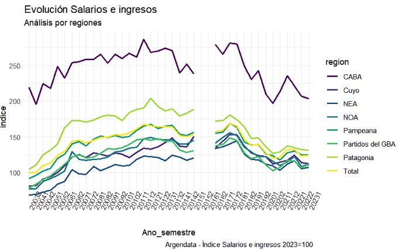

*El ingreso per cápita familiar se deflacta por el valor de la línea de pobreza que corresponde a cada región y período. Además, el valor de cada región está expresado en relación con el promedio nacional, siendo el promedio nacional en el segundo semestre de 2003 = 100. No se encuentran datos correspondientes a los trimestres 02-2014 al 02-2015. Fuente : Argendata

En el período 2018-2023, los ingresos de todas las regiones de Argentina cayeron respecto al 2017. Al mismo tiempo, todas las regiones tienen un menor nivel de ingreso respecto a CABA mostrando la misma tendencia negativa.

Dado que la vivienda es un bien normal, es de esperar que ante una caída del nivel de ingreso disminuya su demanda. Si disminuye la demanda dada la oferta, los precios deberían caer.

Para obtener mayor información sobre esto tomamos una serie recopilada por el Instituto de Estadística y Censos de CABA (IDEEC - CABA) respecto al Precio promedio de publicación de departamentos en alquiler de 1, 2 y 3 ambientes usados y a estrenar para la Ciudad de Buenos Aires, considerando los años 2017 a 2024. Luego, deflactamos con los valores de Indice de Precios al Consumidor (IPC), considerando los mismos años, para obtener los valores reales.

##### **Oferta de Alquileres**

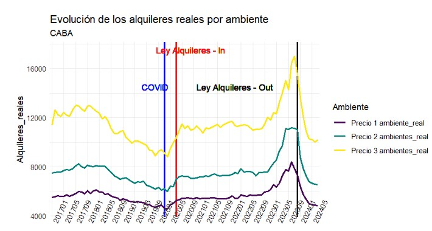

Encontramos tres momentos que cambian la dinámica de los precios:

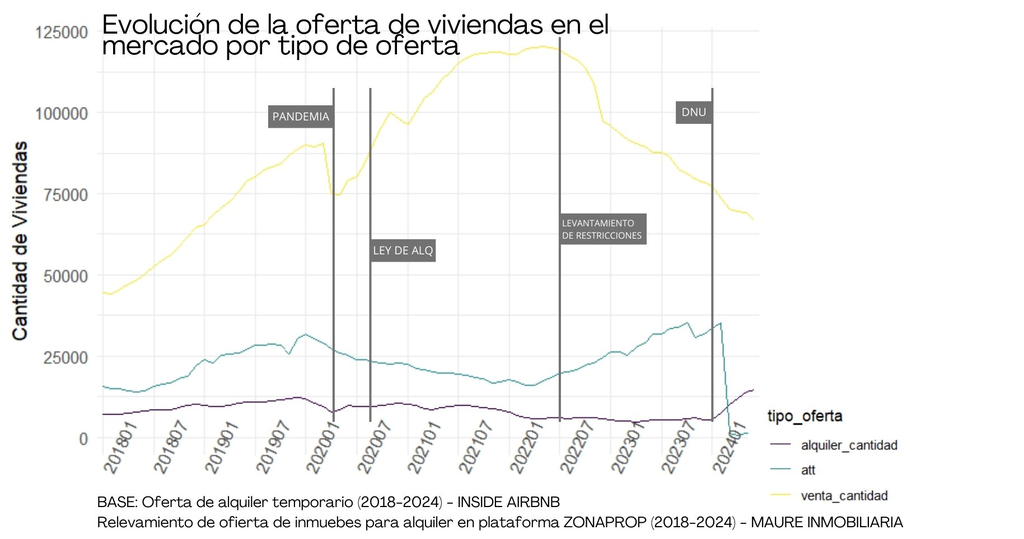

Los datos relevados en Inside Airbnb y por Maure Inmobiliaria permiten ver el aumento de la oferta de alquiler temporario entre el periodo que corresponde a la finalización del ASPO y la sanción del DNU 70/23, y su drastica disminución al comienzo de 2024. Como efecto de esta medida, podemos ver un aumento de las ofertas correspondientes a alquileres tradicionales, estancados en los ultimos años. En relación a las ofertas correspondientes a ventas, si bien siguen siendo mayoritarias, mantienen un ciclo a la baja desde el levantamiento de restricciones.

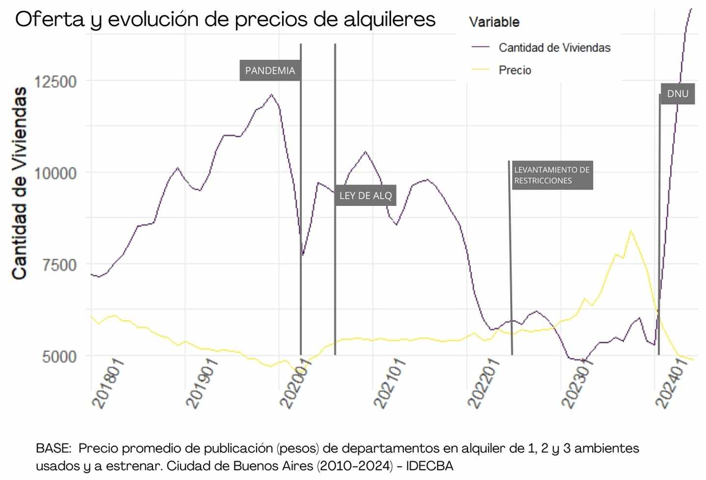

En este sentido, el período de salida del ASPO marca el inicio de un aumento de los precios sostenido hasta los meses previos al DNU, acompañado de una retracción en términos de oferta.

Por otro lado, el levantamiento de las restricciones permitió una recuperación y posterior aumento del total de arribos internacionales, superando niveles históricos al finalizar el año 2022

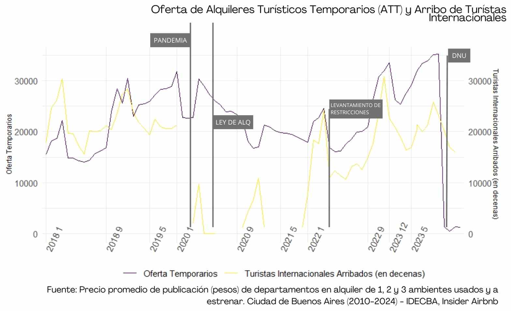

Hasta la sanción del DNU, puede verse una correlación entre el arribo y la oferta de alquileres en modalidad temporaria.

##### **Impactos en los salarios y efectos en la Ciudad Autónoma de Buenos Aires**

Para este análisis, nos centraremos en la Ciudad Autónoma de Buenos Aires, la cual presenta una estructura particular de tenencia de vivienda, con una importante proporción de inquilinos frente a los propietarios.

Así, desde 2003 la cantidad de propietarios ha disminuido en 14pp, representando el 50% del total del stock de vivienda. En la ciudad de Córdoba, por ejemplo, los propietarios representan el 52%, mientras que en la ciudad de Rosario los propietarios equivalen a un 62,6%.

El ASPO producto del COVID-19 impulsa este proceso de inquilinización, a su vez aumenta la tenencia precaria de la vivienda.

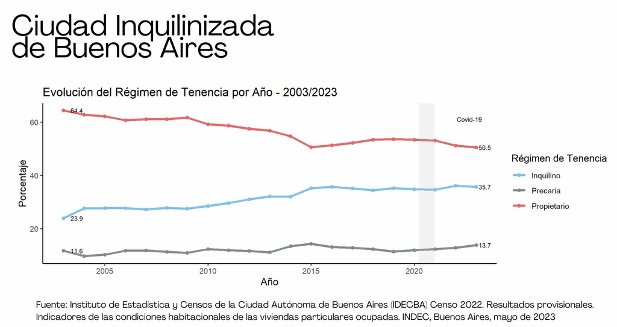

Por otro lado, un análisis de los ingresos encuentra una disminución importante del poder adquisitivo, lo cual repercute en las capacidades para acceder a una vivienda.

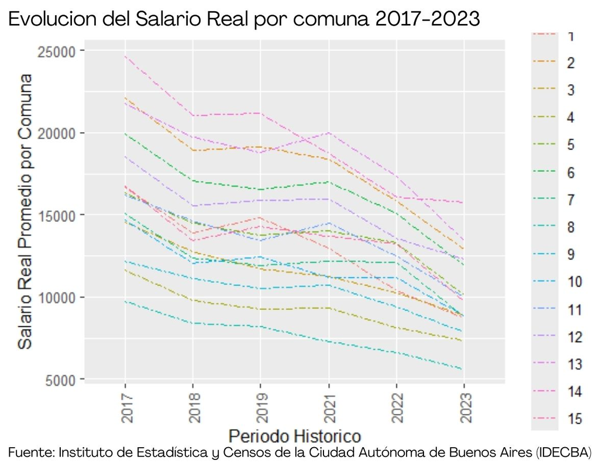

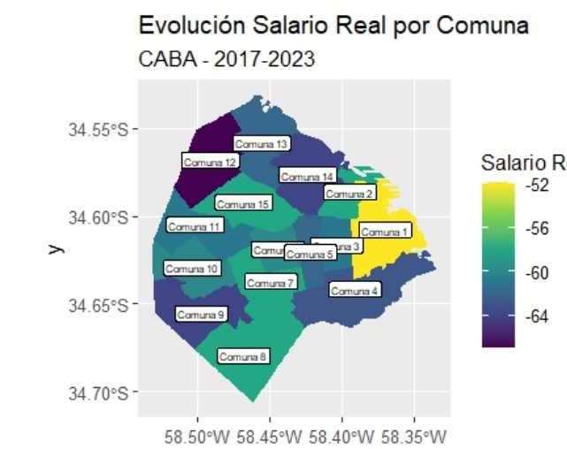

#### **Conclusiones**

En base al trabajo realizado, podemos aproximar las siguientes conclusiones:

- **La ley, aunque aumentó la previsibilidad para los inquilinos, tuvo el efecto no deseado de reducir la oferta de viviendas, limitando el acceso al alquiler.**
- **El *fly to quality* refleja un desplazamiento de la oferta hacia el turismo temporario, impulsado más por expectativas que por rentabilidad real, un resultado imprevisto de las políticas actuales.**
- **La cantidad de oferta disponible se ha revelado como el factor clave en la determinación de los precios, impactando la asequibilidad de manera inesperada.**
- **La liberalización del mercado y la devaluación ha provocado una contracción en la oferta de turismo temporario y un aumento en la oferta de alquileres tradicionales.**